# Nitinat escapement 2024 (PRELIM)

South Coast StA

Last update: 2025-01-07

# 1 **Infilling/specialty expansion of specific surveys**

*This section is reserved for deeper dives into specific surveys or days where specialty expansions might be required (e.g., important sections missed, partial surveys around peak of spawn, etc.). This section could be blank in years where no detailed exploration/analysis is needed to determine a survey’s expansion!*

On Oct 24 we only swam the lower section to calibrate with the heli, focus on Chum, and due to crew shortages. Need to expand potentially for missed upper section.

First, will do this by looking at the ratio of counts between lower and upper.

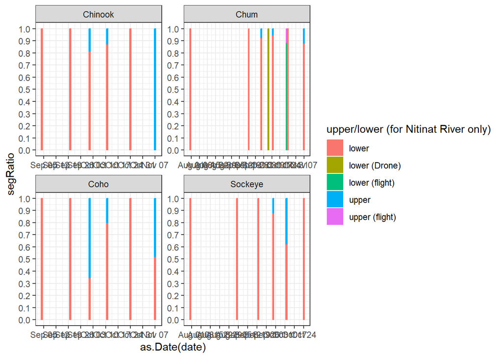

Observations for each species based on graph above:

- Chum: Chum appear to be pretty consistently ~85% in the lower river, whether it was on snorkel surveys or from the heli. Therefore, on Oct 24 lower swim we should probably say *85% population*
- Chinook: Chinook are a bit variable, but tend to have fewer in the upper too. There were essentially no fish left Nov 7 (n=5), so apply last few surveys that where ~80% in lower reaches, therefore *80% population* for Oct 24.
- Coho: Coho tend to push up, and surveys this year may note 2 waves of Coho that went up to upper and on to tribs even. For Oct 24, will apply *50% population*.
- Sockeye: minimal amount, but most should be heading up (or already in) Parker, so will set to *50% population*.

# 2 **Sockeye**

Snorkel and heli surveys were primarily timed for Chinook and Chum. Sockeye counts are incidental and should be considered low-quality/incomplete. Very low water this summer likely resulted in a barrier to migration, preventing sockeye from reaching Parker Creek until rains came much later. For this reason, SK counts in 2023 may be much higher than previous years as they were trapped in the lower mainstem and more visible to surveyors in late August.

## 2.1 Area 21-22 raw vs expanded counts

Counts are expanded for both % population surveyed and/or observer efficiency, depending on survey conditions.

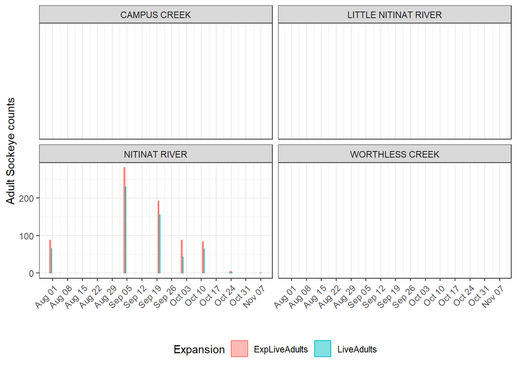

Figure: Live Adult sockeye raw counts (blue) and counts expanded for % population and/or OE (pink).

## 2.2 Counts & environmentals

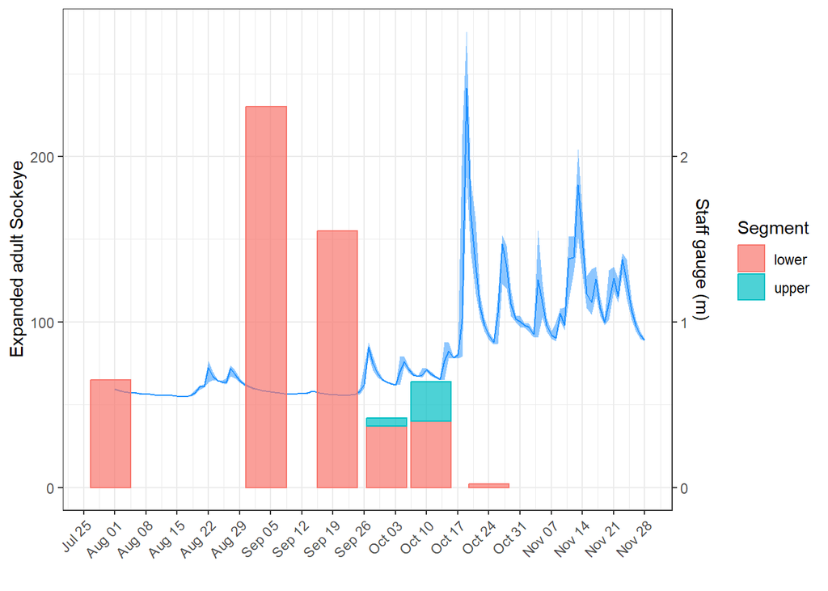

Figure: Sockeye counts (raw live adults), water levels (blue line)

## 2.3 Behaviour & carcasses

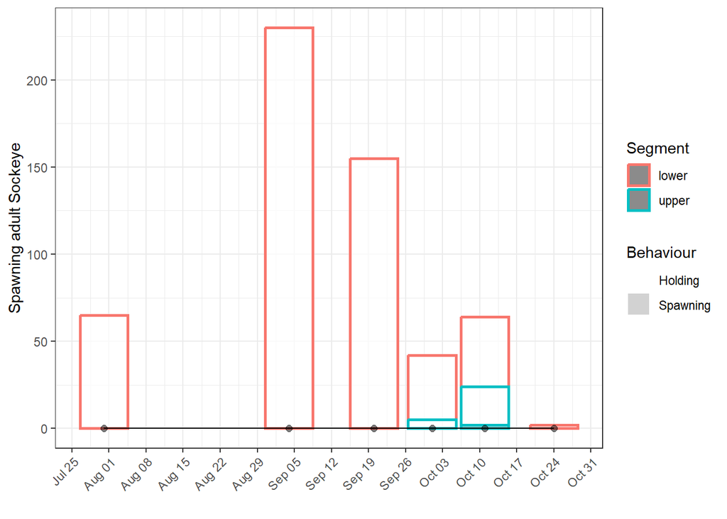

## 2.4 Snorkel & swim-in counts

There are no swim-ins for Nitinat sockeye as they are not enhanced.

## 2.5 Tributaries (River and Lake)

Sockeye were present in Hobiton and Campus Creeks in 2023, but the primary enumeration method is by NTC and DFN echosounder. Hobiton was swum once late May due to delays in the echosounder installation, and again in late August during drought conditions to assess whether pre-spawn mortalities were occurring in the creek. Only one pre-spawn jack was noted, the remaining dead were too deep or too decomposed to assess mortality.

| date | system | exp_ad_live | dead_adults | jk_live | jk_dead |
| --- | --- | --- | --- | --- | --- |
| 2024-10-23 | Hobiton Creek | 8 | 0 | 0 | 0 |

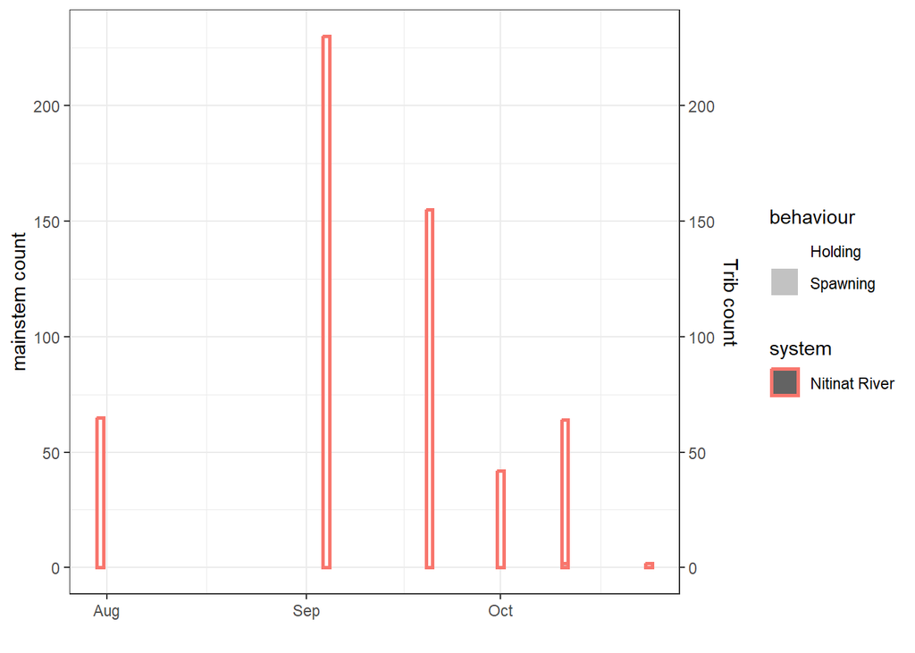

Figure: Mainstem Nitinat (pink) and trib (blue) counts for Sockeye adults (raw).

## 2.6 AUC assessments

The information below is meant to assist with determining if AUC is an appropriate method, and whether to include/exclude certain surveys. **Note that removals of surveys that are deemed irrelevant for a species/year has already been in the database prior to exporting the AUCresults file. This script does not really help with that unless you “restore to default” AUC data in the database and do some extra plotting yourself**

Table: AUC math for systems receiving AUC estimate in 2024

```
## # A tibble: 10 × 13
##    WatershedCode           Year ShortSpecies DateRange NoOfDays RawAdultFishDays
##    <chr>                  <dbl> <chr>        <chr>        <dbl>            <dbl>
##  1 930-071700-00000-0000…  2024 SK           2024/07/…       30             975
##  2 930-071700-00000-0000…  2024 SK           2024/07/…       35            5162.
##  3 930-071700-00000-0000…  2024 SK           2024/09/…       16            3080
##  4 930-071700-00000-0000…  2024 SK           2024/09/…       11            1084.
##  5 930-071700-00000-0000…  2024 SK           2024/10/…       10             530
##  6 930-071700-00000-0000…  2024 SK           2024/10/…       13             429
##  7 930-071700-00000-0000…  2024 SK           2024/10/…       14              14
##  8 930-071700-00000-0000…  2024 SK           2024/11/…        3               0
##  9 930-071700-37600-0000…  2024 SK           2024/09/…       53              NA
## 10 930-071700-37600-0000…  2024 SK           2024/10/…       22               0
## # ℹ 7 more variables: RawJackFishDays <dbl>, ExpAdultFishDays <dbl>,
## #   ExpJackFishDays <dbl>, AREA <chr>, n <int>, SystemName <chr>, method <chr>
```

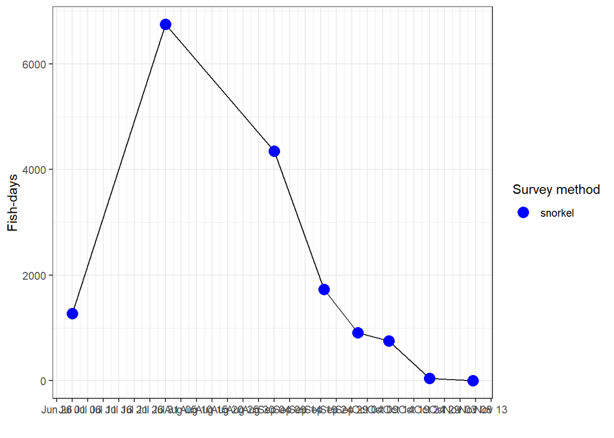

Figure: AUC curve for Nitinat mainstem Sockeye. Note in 2023 this had already excluded the heli survey, but in future would likely also include the flight for reference.

## 2.7 Area 21-22 preliminary escapement estimates

Table: Raw swim data (raw and expanded live and dead) for Sockeye.

| ShortSpecies | Section_AreaInspected | SDate | WaterTemperature | WaterClarity | LiveAdults | DeadAdults | LiveJacks | DeadJacks | ExpLiveAdults | ExpDeadAdults | ExpLiveJacks | ExpDeadJacks | OverallReliability | EstPctSeen |
| --- | --- | --- | --- | --- | --- | --- | --- | --- | --- | --- | --- | --- | --- | --- |
| SK | CAMPUS CREEK | 2024-11-01 | 9.5 | 3 - 5 m or to Bottom | NA | NA | NA | NA | NA | NA | NA | NA | NA | NA |
| SK | LITTLE NITINAT RIVER | 2024-10-24 | 99.0 | 1 - 3 m | NA | NA | NA | NA | NA | NA | NA | NA | NA | NA |
| SK | NITINAT RIVER | 2024-07-31 | 14.0 | 3 - 5 m or to Bottom | 65 | NA | NA | NA | 88 | NA | NA | NA | M | 0.85 |
| SK | NITINAT RIVER | 2024-09-04 | 13.0 | 3 - 5 m or to Bottom | 230 | 0 | NA | NA | 281 | NA | NA | NA | H | 0.85 |
| SK | NITINAT RIVER | 2024-09-20 | 14.0 | 3 - 5 m or to Bottom | 155 | 0 | 0 | NA | 192 | NA | NA | NA | H | 0.85 |
| SK | NITINAT RIVER | 2024-10-01 | 11.0 | 3 - 5 m or to Bottom | 42 | NA | NA | NA | 88 | NA | NA | NA | M | 0.90 |
| SK | NITINAT RIVER | 2024-10-11 | 11.0 | NA | 64 | NA | 1 | NA | 83 | NA | NA | NA | H | 0.90 |
| SK | NITINAT RIVER | 2024-10-23 | 99.0 | 1 - 3 m | 0 | NA | NA | NA | NA | NA | NA | NA | NA | NA |
| SK | NITINAT RIVER | 2024-10-24 | 8.0 | 1 - 3 m | 2 | NA | NA | NA | 4 | NA | NA | NA | L | 0.50 |
| SK | NITINAT RIVER | 2024-11-07 | 8.0 | 1 - 3 m | 0 | NA | NA | NA | 0 | NA | NA | NA | NA | 1.00 |
| SK | WORTHLESS CREEK | 2024-10-24 | 99.0 | 1 - 3 m | NA | NA | NA | NA | NA | NA | NA | NA | NA | NA |
| SK | WORTHLESS CREEK | 2024-11-01 | 99.0 | 3 - 5 m or to Bottom | NA | NA | NA | NA | NA | NA | NA | NA | NA | NA |

Table: Escapement estimates for each system.

[output not shown]

## 2.8 2024 compared to historical run timing and abundance

Run timing information is not available for Nitinat Sockeye.

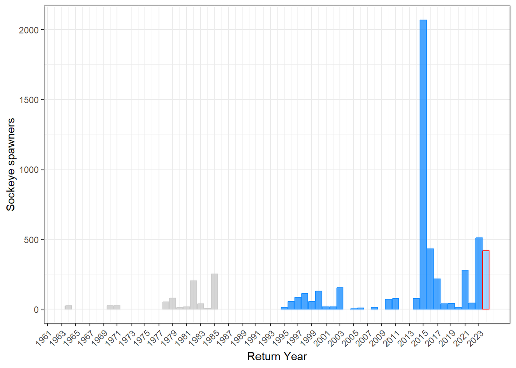

Figure: 2024 preliminary adult Sockeye escapement estimate (red outline) relative to historical adult (blue) and unspecified (gray) escapement estimates. Gaps indicate years without estimates.

# 3 **Coho**

## 3.1 Area 21-22 raw vs expanded counts

Counts are expanded for both % population surveyed and/or observer efficiency, depending on survey conditions.

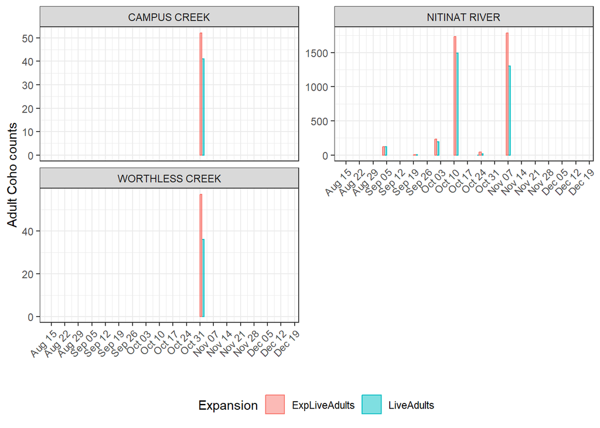

s Figure: Live Adult Coho raw counts (blue) and counts expanded for % population and/or OE (pink).

## 3.2 Counts & environmentals

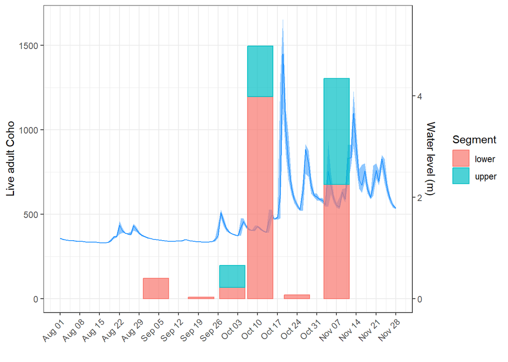

Figure: Coho counts (raw live adults) and water levels (blue line)

## 3.3 Behaviour & carcasses

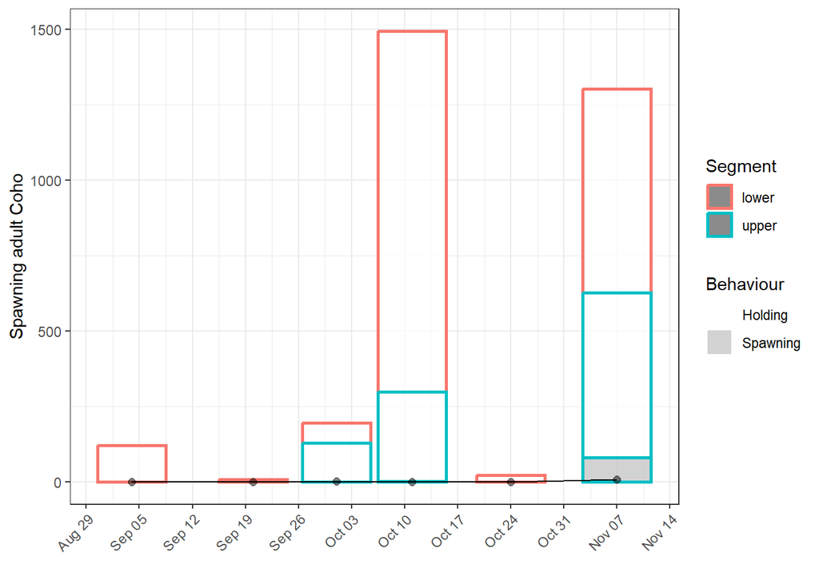

Figure: Expanded live adult Coho (bars) and carcasses (black line). Bar fill indicates behaviour (spawning=gray, holding=white), bar outline indicates river segment (upper=blue, lower=pink).

## 3.4 Snorkel, angling & swim-in counts

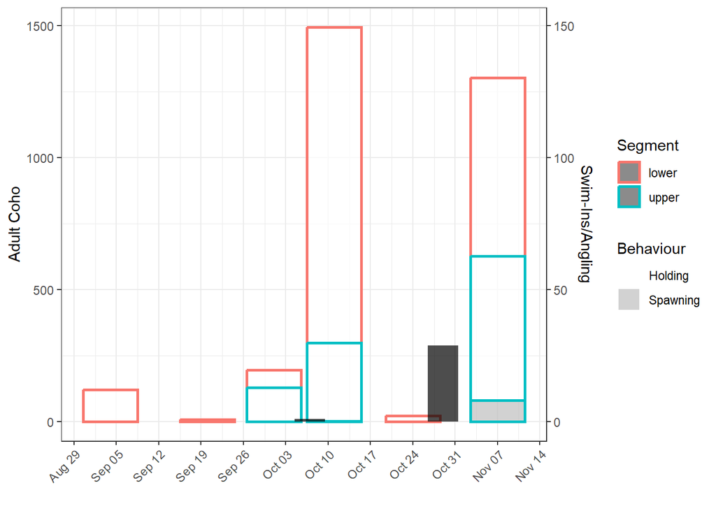

Figure: Expanded adult Coho counts (large bars) and ALL swim-ins (narrow black bars, including jacks). Adult bar fill colours indicate behaviour (spawning=gray, holding=white), bar line colour indicates river segment (lower=pink, upper=blue).

## 3.5 Mark rate in lake

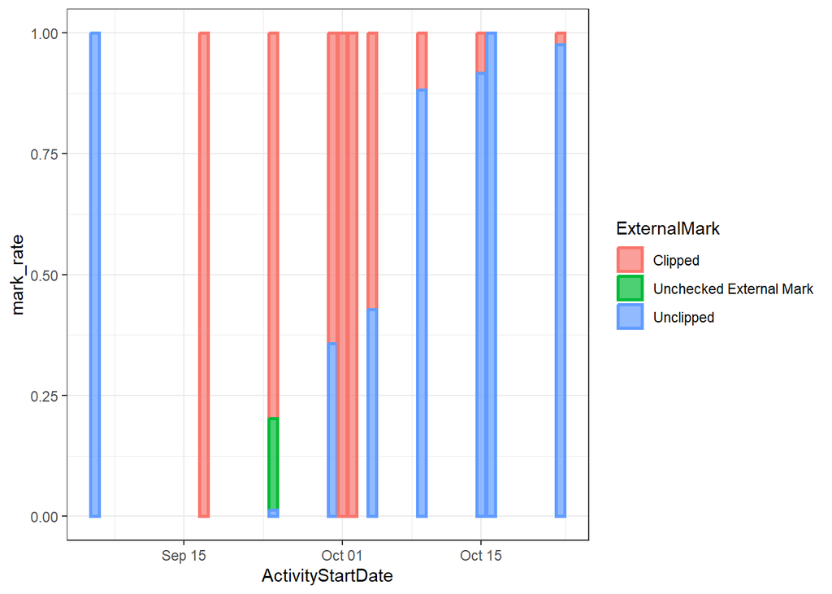

Figure: Mark rate of all coho caught in purse seine catches in Nitinat Lake. Excluded gillnet catch as mark rate is typically not examined.

The overall mark rate of **ALL coho** caught in Nitinat Lake purse seine this year was **37.3%**.

The overall mark rate of **ADULT coho** caught in Nitinat Lake purse seine this year was **31%**.

## 3.6 Tributaries (River and Lake)

| trib_status | system | exp_ad_live | dead_adults |
| --- | --- | --- | --- |
| Nitinat Lake trib | Campus Creek | 47 | 1 |
| Nitinat River trib | Worthless Creek | 40 | 0 |

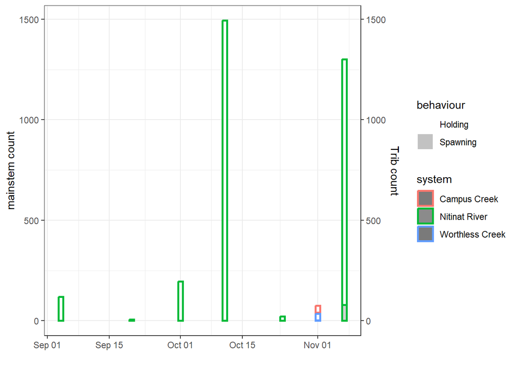

## 3.7 AUC assessments

The information below is meant to assist with determining if AUC is an appropriate method, and whether to include/exclude certain surveys.

Table: AUC math for systems receiving AUC estimate in 2024

```
## # A tibble: 7 × 13
##   WatershedCode            Year ShortSpecies DateRange NoOfDays RawAdultFishDays
##   <chr>                   <dbl> <chr>        <chr>        <dbl>            <dbl>
## 1 930-071700-00000-00000…  2024 CO           2024/08/…       20            1200
## 2 930-071700-00000-00000…  2024 CO           2024/09/…       16            1016
## 3 930-071700-00000-00000…  2024 CO           2024/09/…       11            1111
## 4 930-071700-00000-00000…  2024 CO           2024/10/…       10            8445
## 5 930-071700-00000-00000…  2024 CO           2024/10/…       13            9848.
## 6 930-071700-00000-00000…  2024 CO           2024/10/…       14            9261
## 7 930-071700-00000-00000…  2024 CO           2024/11/…       54           35154
## # ℹ 7 more variables: RawJackFishDays <dbl>, ExpAdultFishDays <dbl>,
## #   ExpJackFishDays <dbl>, AREA <chr>, n <int>, SystemName <chr>, method <chr>
```

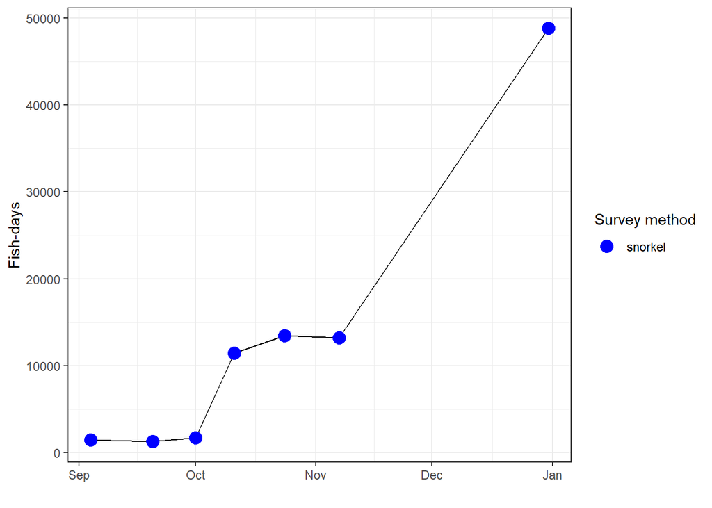

Figure: AUC curve for Nitinat mainstem Coho. Note in 2023 this had already excluded the heli survey, but in future would likely also include the flight for reference.

## 3.8 Area 21-22 preliminary escapement estimates (AUC/PL+D)

Table: Raw swim data (raw and expanded live and dead) for Coho.

| ShortSpecies | Section_AreaInspected | SDate | WaterTemperature | WaterClarity | LiveAdults | DeadAdults | LiveJacks | DeadJacks | ExpLiveAdults | ExpDeadAdults | ExpLiveJacks | ExpDeadJacks | OverallReliability | EstPctSeen |
| --- | --- | --- | --- | --- | --- | --- | --- | --- | --- | --- | --- | --- | --- | --- |
| CO | CAMPUS CREEK | 2024-11-01 | 9.5 | 3 - 5 m or to Bottom | 41 | 1 | 6 | NA | 52 | NA | NA | NA | M | 0.9 |
| CO | LITTLE NITINAT RIVER | 2024-10-24 | 99.0 | 1 - 3 m | NA | NA | NA | NA | NA | NA | NA | NA | NA | NA |
| CO | NITINAT RIVER | 2024-07-31 | 14.0 | 3 - 5 m or to Bottom | NA | NA | NA | NA | NA | NA | NA | NA | NA | NA |
| CO | NITINAT RIVER | 2024-09-04 | 13.0 | 3 - 5 m or to Bottom | 120 | 0 | 6 | NA | 124 | NA | NA | NA | H | 1.0 |
| CO | NITINAT RIVER | 2024-09-20 | 14.0 | 3 - 5 m or to Bottom | 7 | 0 | 0 | NA | 7 | NA | NA | NA | H | 1.0 |
| CO | NITINAT RIVER | 2024-10-01 | 11.0 | 3 - 5 m or to Bottom | 195 | NA | 20 | NA | 232 | NA | NA | NA | M | 1.0 |
| CO | NITINAT RIVER | 2024-10-11 | 11.0 | NA | 1494 | NA | 173 | NA | 1732 | NA | NA | NA | H | 1.0 |
| CO | NITINAT RIVER | 2024-10-23 | 99.0 | 1 - 3 m | 0 | NA | NA | NA | NA | NA | NA | NA | NA | NA |
| CO | NITINAT RIVER | 2024-10-24 | 8.0 | 1 - 3 m | 21 | NA | 4 | NA | 46 | NA | NA | NA | L | 0.5 |
| CO | NITINAT RIVER | 2024-11-07 | 8.0 | 1 - 3 m | 1302 | 8 | 148 | NA | 1784 | NA | NA | NA | M | 0.9 |
| CO | WORTHLESS CREEK | 2024-10-24 | 99.0 | 1 - 3 m | NA | NA | NA | NA | NA | NA | NA | NA | NA | NA |
| CO | WORTHLESS CREEK | 2024-11-01 | 99.0 | 3 - 5 m or to Bottom | 36 | 0 | 8 | NA | 57 | NA | NA | NA | M | 0.7 |

Table: Escapement estimates for each system.

[output not shown]

### 3.8.1 Estimate decision:

For 2024 prelim decision used AUC with SL=30 days because saw a decline in counts and observed the start of spawning in the upper Nitinat on the last survey. However, noted that swim-ins entered hatchery before the final count, so can assume a lot of the fish seen in the lower on Oct 10 may have swum into the hatchery on their way to the upper (Nov 7). 30 day SL seems reasonable based on past values and behaviour (no evidence of delayed entry/rapid spawning). AUC with SL=30 gives 3,050 adults and 344 jacks (which also covers the raw peak live count); removing swim-ins (279 adults, 18 jacks) **results in a natural spawner estimate of 2771 adults and 326 jacks**. This does not include Lake broodstock or Worthless coho (57 adults, 13 jacks). There was no angled broodstock this year. *This is subject to change; see EscBatchHardCopy report for specific estimate abundance.*

**confirm add/subtract of worthless fish… i think last year subtracted in a similar situation as this year…**

## 3.9 2024 compared to historical run timing and abundance

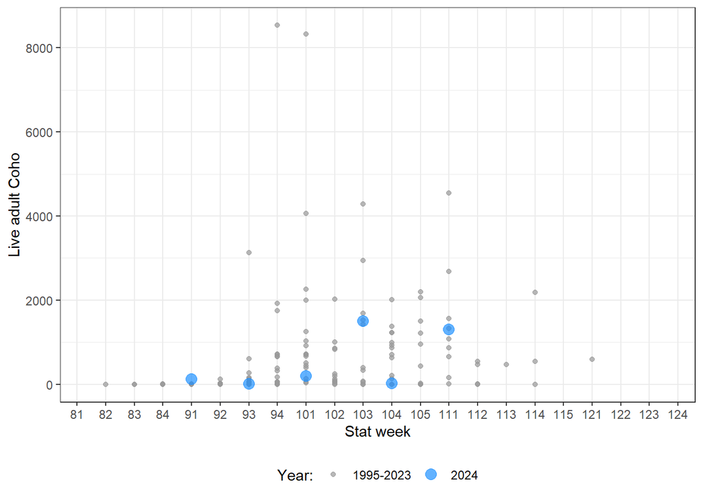

Figure: Raw swim counts (blue) from this year compared to historical raw swim counts. Stat weeks indicate the month (8=August, 12=December) and week of momth (1=first week, 2=2nd week, etc.), e.g., 81=First week of August, 91=First week of September, etc.

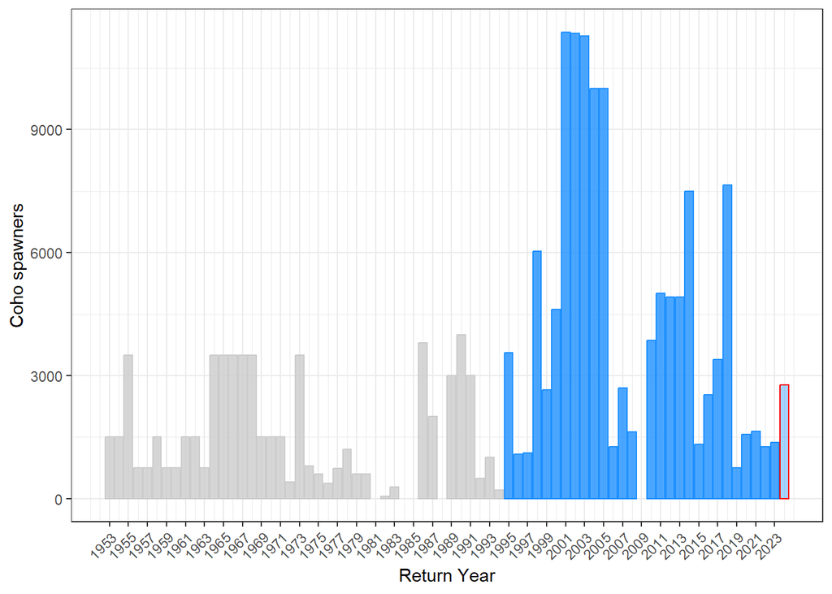

Figure: 2024 preliminary adult Coho escapement estimate (red outline) relative to historical adult (blue) and unspecified (gray) escapement estimates. Gaps indicate years without estimates.

# 4 **Chum**

Six snorkel surveys and one helicopter survey were conducted for Chum in 2023. The heli survey may have been slightly early for Chum.

## 4.1 Area 21-22 raw vs expanded counts

Counts are expanded for both % population surveyed and/or observer efficiency, depending on survey conditions.

[figure not shown]

Figure: Live Adult Chum raw counts (blue) and counts expanded for % population and/or OE (pink).

## 4.2 Counts & environmentals

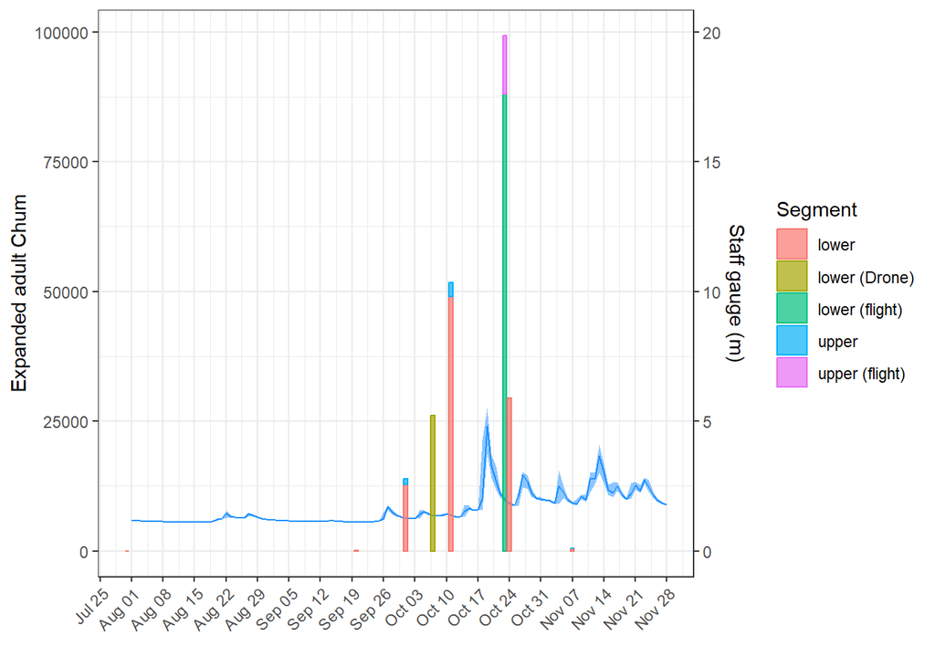

## 4.3 Behaviour & carcasses

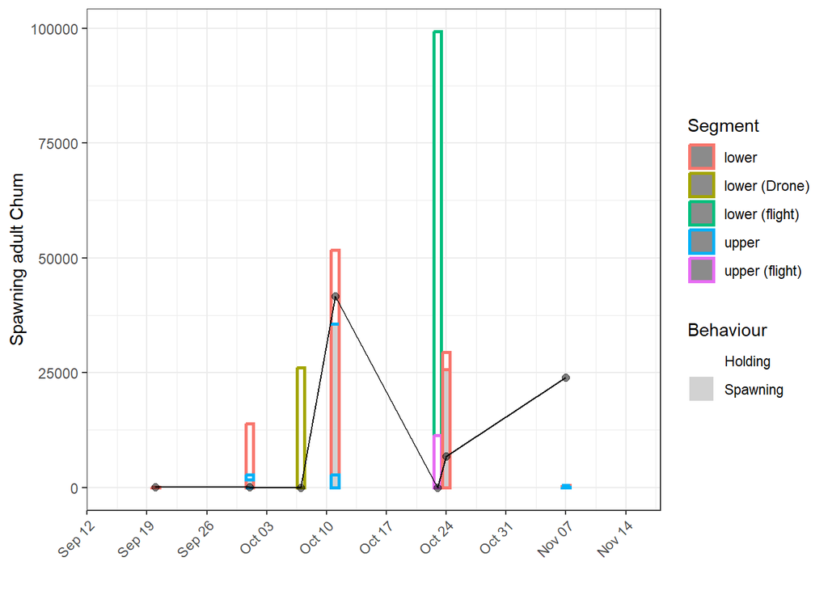

Figure: Expanded live adult Chum (bars) and carcasses (black line). Bar fill indicates behaviour (spawning=gray, holding=white), bar outline indicates river segment (upper=blue, lower=pink)

## 4.4 Snorkel & swim-in counts

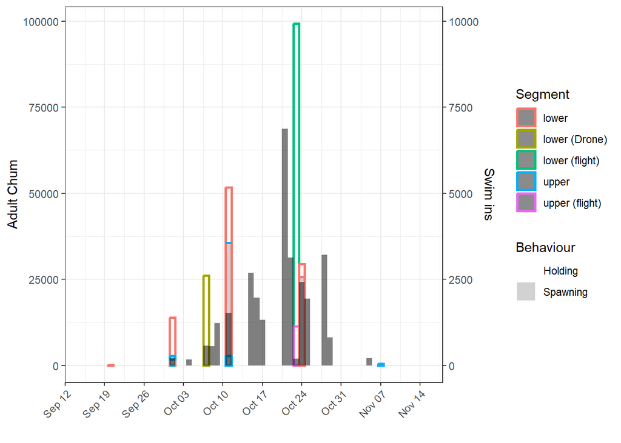

Figure: Expanded Chum counts (large bars) and swim-ins (narrow black bars). Adult bar fill colours indicate behaviour (spawning=gray, holding=white), bar line colour indicates river segment (lower=pink, upper=blue).

## 4.5 Tributaries (River and Lake)

| system | exp_ad_live | dead_adults |
| --- | --- | --- |
| Campus Creek | 2008 | 3752 |
| Hobiton Creek | 2525 | 5 |
| Little Nitinat | 380 | NA |
| Worthless Creek | 460 | NA |

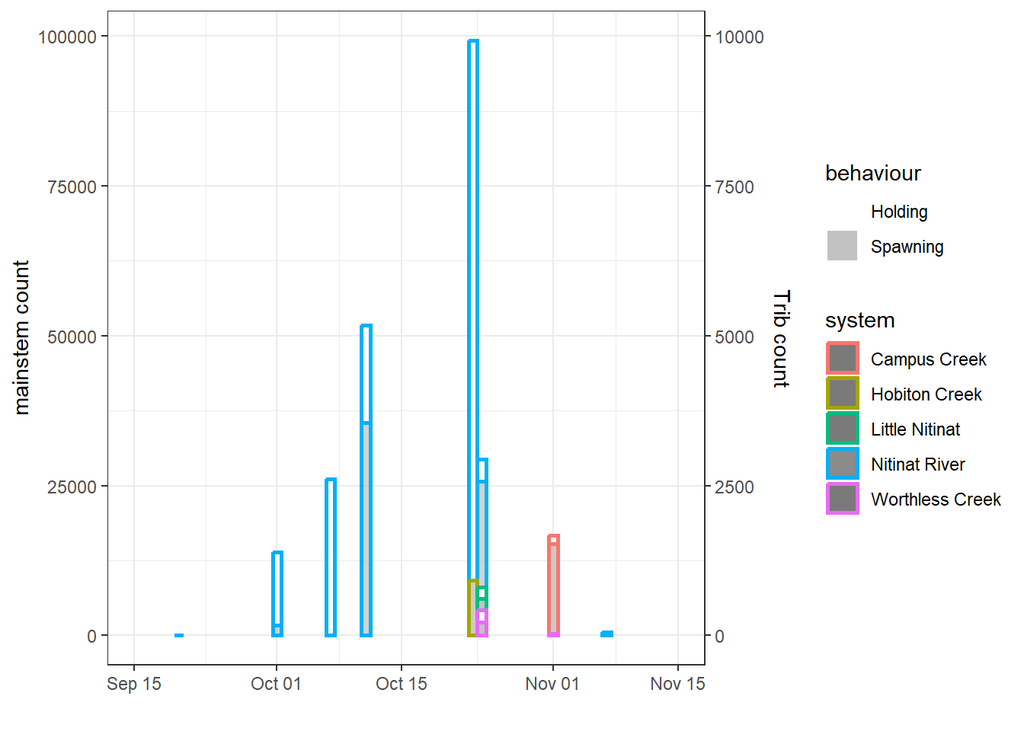

## 4.6 AUC assessments

The information below is meant to assist with determining if AUC is an appropriate method, and whether to include/exclude certain surveys.

Table: AUC math for systems receiving AUC estimate in 2024

```
## # A tibble: 9 × 13
##   WatershedCode            Year ShortSpecies DateRange NoOfDays RawAdultFishDays
##   <chr>                   <dbl> <chr>        <chr>        <dbl>            <dbl>
## 1 930-071700-00000-00000…  2024 CM           2024/07/…       38               0
## 2 930-071700-00000-00000…  2024 CM           2024/09/…       16             648
## 3 930-071700-00000-00000…  2024 CM           2024/09/…       11           76664.
## 4 930-071700-00000-00000…  2024 CM           2024/10/…       10          328010
## 5 930-071700-00000-00000…  2024 CM           2024/10/…       12          905964
## 6 930-071700-00000-00000…  2024 CM           2024/10/…       15          748072.
## 7 930-071700-00000-00000…  2024 CM           2024/11/…       23            5670.
## 8 930-071700-37600-00000…  2024 CM           2024/09/…       53           10070
## 9 930-071700-37600-00000…  2024 CM           2024/10/…       22            4180
## # ℹ 7 more variables: RawJackFishDays <dbl>, ExpAdultFishDays <dbl>,
## #   ExpJackFishDays <dbl>, AREA <chr>, n <int>, SystemName <chr>, method <chr>
```

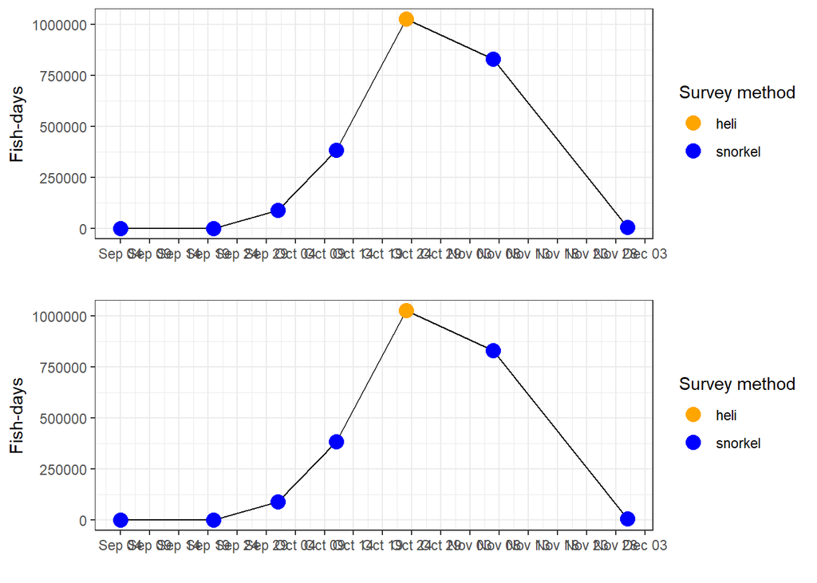

Figure: AUC curve for Nitinat mainstem Chum.

## 4.7 Area 21-22 preliminary escapement estimates (AUC)

Table: Raw swim data (raw and expanded live and dead) for Chum.

| ShortSpecies | Section_AreaInspected | SDate | WaterTemperature | WaterClarity | LiveAdults | DeadAdults | LiveJacks | DeadJacks | ExpLiveAdults | ExpDeadAdults | ExpLiveJacks | ExpDeadJacks | OverallReliability | EstPctSeen |
| --- | --- | --- | --- | --- | --- | --- | --- | --- | --- | --- | --- | --- | --- | --- |
| CM | CAMPUS CREEK | 2024-11-01 | 9.5 | 3 - 5 m or to Bottom | 1638 | 3752 | NA | NA | 2231 | NA | NA | NA | M | 0.90 |
| CM | LITTLE NITINAT RIVER | 2024-10-24 | 99.0 | 1 - 3 m | 380 | NA | NA | NA | 380 | NA | NA | NA | H | 1.00 |
| CM | NITINAT RIVER | 2024-07-31 | 14.0 | 3 - 5 m or to Bottom | 1 | NA | NA | NA | 1 | NA | NA | NA | M | 1.00 |
| CM | NITINAT RIVER | 2024-09-04 | 13.0 | 3 - 5 m or to Bottom | 0 | NA | NA | NA | NA | NA | NA | NA | NA | NA |
| CM | NITINAT RIVER | 2024-09-20 | 14.0 | 3 - 5 m or to Bottom | 81 | 1 | NA | NA | 93 | NA | NA | NA | H | 0.95 |
| CM | NITINAT RIVER | 2024-10-01 | 11.0 | 3 - 5 m or to Bottom | 13858 | 5 | NA | NA | 16393 | NA | NA | NA | M | 1.00 |
| CM | NITINAT RIVER | 2024-10-11 | 11.0 | NA | 51744 | 4168 | NA | NA | 63081 | NA | NA | NA | H | 1.00 |
| CM | NITINAT RIVER | 2024-10-23 | 99.0 | 1 - 3 m | 99250 | 3000 | NA | NA | 99250 | NA | NA | NA | H | 1.00 |
| CM | NITINAT RIVER | 2024-10-24 | 8.0 | 1 - 3 m | 29419 | 680 | NA | NA | 44801 | NA | NA | NA | M | 0.85 |
| CM | NITINAT RIVER | 2024-11-07 | 8.0 | 1 - 3 m | 493 | 2388 | NA | NA | 642 | NA | NA | NA | M | 1.00 |
| CM | WORTHLESS CREEK | 2024-10-24 | 99.0 | 1 - 3 m | 430 | NA | NA | NA | 478 | NA | NA | NA | H | 0.90 |
| CM | WORTHLESS CREEK | 2024-11-01 | 99.0 | 3 - 5 m or to Bottom | 27 | 186 | NA | NA | 33 | NA | NA | NA | M | 0.90 |

Table: Escapement estimates for each system.

| Year | SystemName | AREA | ShortSpecies | StartingZeroDate | EndingZeroDate | AdultShortResidenceTime | AdultMidResidenceTime_R | AdultLongResidenceTime | JackShortResidenceTime | JackMidResidenceTime_R | JackLongResidenceTime | AUCTotalDays | AdultExpAUCLowValue | AdultExpAUCMidValue_R | AdultExpAUCHighValue | JackExpAUCLowValue | JackExpAUCMidValue_R | JackExpAUCHighValue | AdultExpPLD | JackExpPLD | FinalAdultEstimate | AdultRemovalsReco | FinalJackEstimate | JackRemovalsReco | AdultRemovalsIncluded | JackRemovalsIncluded | EnumerationClass | Notes | IsFinal |
| --- | --- | --- | --- | --- | --- | --- | --- | --- | --- | --- | --- | --- | --- | --- | --- | --- | --- | --- | --- | --- | --- | --- | --- | --- | --- | --- | --- | --- | --- |
| 2024 | Nitinat River, Nitinat Lake | 22 | CM | 2024-07-28 | 2024-11-30 | 8 | 9 | 10 | 8 | 9 | 10 | 125 | 234133 | 260147 | 292666 | 0 | 0 | 0 | 113278 | 0 | 260147 | 49424 | 0 | 0 | FALSE | FALSE | 3 | 6 snorkel surveys (31-July to 7 Nov) of which 3 were Upper+Lower (Oct 1, Oct 11, Nov 7) - not all swims retained for AUC estimate (e.g., 31 July). Sept 20 % pop reduced as chum were starting to arrive… | FALSE |
| 2024 | Hobiton Creek | 22 | CM | 2024-09-01 | 2024-11-15 | 15 | 20 | 25 | 15 | 20 | 25 | 0 | 0 | 0 | 0 | 0 | 0 | 0 | 0 | 0 | 0 | 0 | 0 | 0 | FALSE | FALSE | 0 | NA | FALSE |
| 2024 | Campus Creek | 22 | CM | 2024-09-01 | 2024-11-15 | 15 | 20 | 25 | 15 | 20 | 25 | 75 | 3033 | 3792 | 5056 | 0 | 0 | 0 | 6191 | 0 | 6191 | 0 | 0 | 0 | FALSE | FALSE | 5 | One survey was conducted Nov 1st of Campus creek, side channel and Borrow Pits. Surveys were entered over 2 days in the database as there were 2 SILs, but added together here for total accounting. Sur… | FALSE |
| 2024 | Little Nitinat River | 22 | CM | 2024-09-01 | 2024-11-15 | 15 | 20 | 25 | 15 | 20 | 25 | 75 | 633 | 792 | 1056 | 0 | 0 | 0 | 422 | 0 | 422 | 0 | 0 | 0 | FALSE | FALSE | 5 | One heli survey Oct 24. Type-5 due to single heli survey. More chum holding/spawning closer to Nitinat confluence. Used PL+D expanded. | FALSE |
| 2024 | Worthless Creek | 22 | CM | 2024-09-01 | 2024-11-15 | 15 | 20 | 25 | 15 | 20 | 25 | 75 | 745 | 931 | 1242 | 0 | 0 | 0 | 597 | 0 | 597 | 0 | 0 | 0 | FALSE | FALSE | 5 | Two surveys: spot check with heli Oct 24, snorkel Nov 1. Despite some difficulties counting from heli (vegetation), used heli explanded PL+D as timing was better. Reduced OE to 80% to account for diff… | FALSE |

## 4.8 2024 compared to historical run timing

[figure not shown]

Figure: Raw swim counts (blue) from this year compared to historical raw swim counts. Stat weeks indicate the month (8=August, 12=December) and week of momth (1=first week, 2=2nd week, etc.), e.g., 81=First week of August, 91=First week of September, etc.

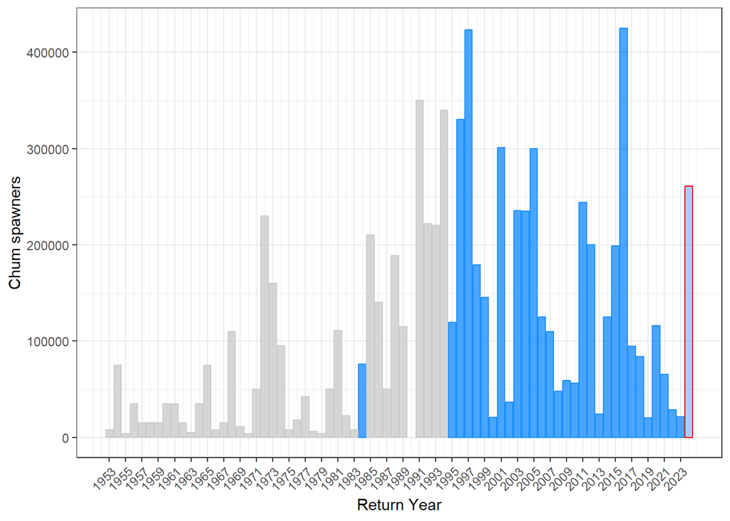

# 5 **Chinook**

## 5.1 Area 21-22 raw vs expanded counts

Counts are expanded for both % population surveyed and/or observer efficiency, depending on survey conditions.

[figure not shown]

Figure: Live Adult Chinook raw counts (blue) and counts expanded for % population and/or OE (pink).

## 5.2 Counts & environmentals

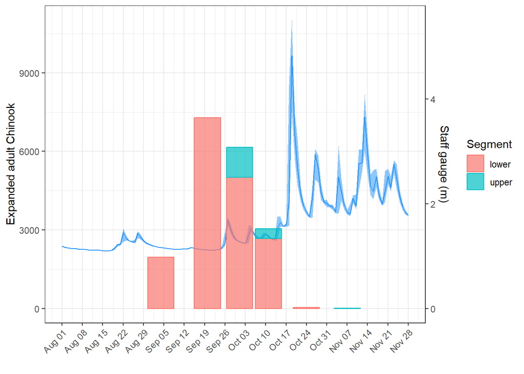

Figure: Chinook counts (raw live adults), water levels (blue line)

## 5.3 Behaviour & carcasses

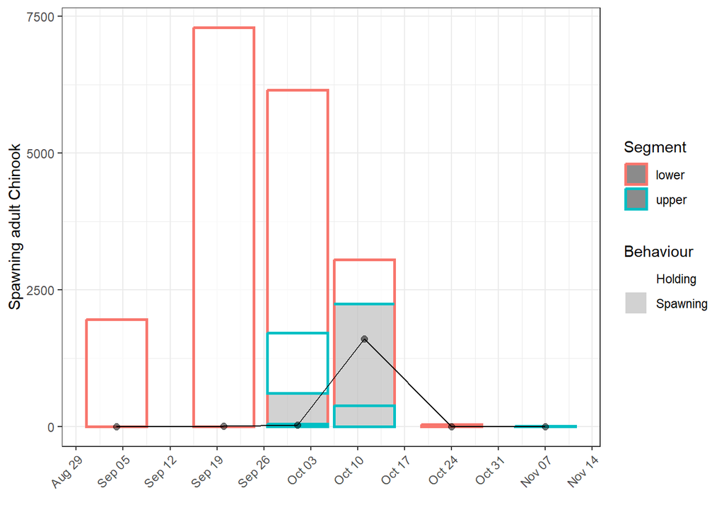

Figure: Expanded live adult Chinook (bars) and carcasses (black line). Bar fill indicates behaviour (spawning=gray, holding=white), bar outline indicates river segment (upper=blue, lower=pink).

## 5.4 Snorkel & swim-in counts

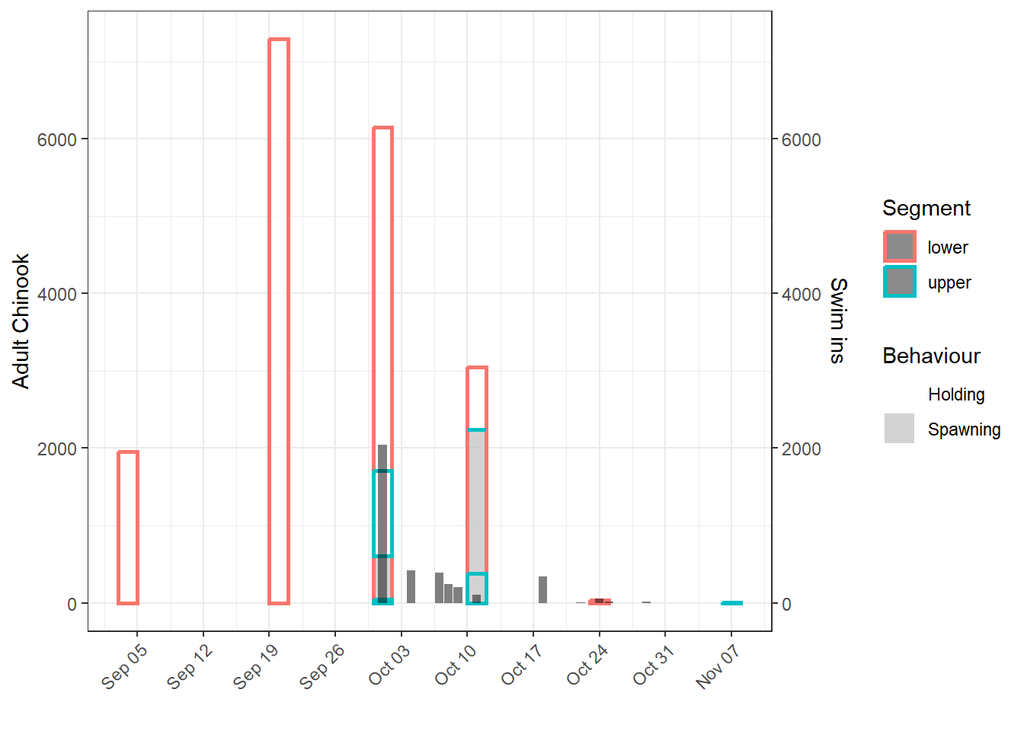

Figure: Expanded adult Chinook counts (large bars) and swim-ins (narrow black bars). Adult bar fill colours indicate behaviour (spawning=gray, holding=white), bar line colour indicates river segment (lower=pink, upper=blue).

Total number of swim-ins this year is: 3869, of which 3817 were adults.

## 5.5 Tributaries (River and Lake)

| system | exp_ad_live | dead_adults |
| --- | --- | --- |
| Campus Creek | 2 | 0 |

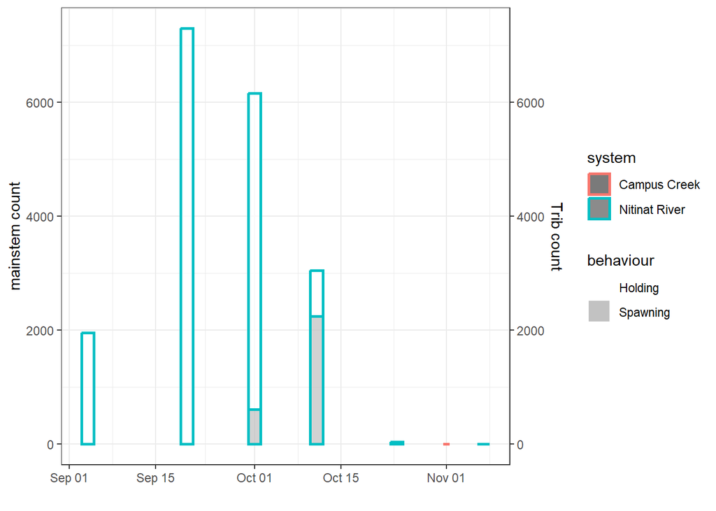

## 5.6 AUC assessments

The information below is meant to assist with determining if AUC is an appropriate method, and whether to include/exclude certain surveys.

Table: AUC math for systems receiving AUC estimate in 2024

```
## # A tibble: 9 × 13
##   WatershedCode            Year ShortSpecies DateRange NoOfDays RawAdultFishDays
##   <chr>                   <dbl> <chr>        <chr>        <dbl>            <dbl>
## 1 930-071700-00000-00000…  2024 CN           2024/08/…       20            19550
## 2 930-071700-00000-00000…  2024 CN           2024/09/…       16            73984
## 3 930-071700-00000-00000…  2024 CN           2024/09/…       11            73942
## 4 930-071700-00000-00000…  2024 CN           2024/10/…       10            46000
## 5 930-071700-00000-00000…  2024 CN           2024/10/…       13            20072
## 6 930-071700-00000-00000…  2024 CN           2024/10/…       14              301
## 7 930-071700-00000-00000…  2024 CN           2024/11/…        8               16
## 8 930-071700-37600-00000…  2024 CN           2024/09/…       53               NA
## 9 930-071700-37600-00000…  2024 CN           2024/10/…       22                0
## # ℹ 7 more variables: RawJackFishDays <dbl>, ExpAdultFishDays <dbl>,
## #   ExpJackFishDays <dbl>, AREA <chr>, n <int>, SystemName <chr>, method <chr>
```

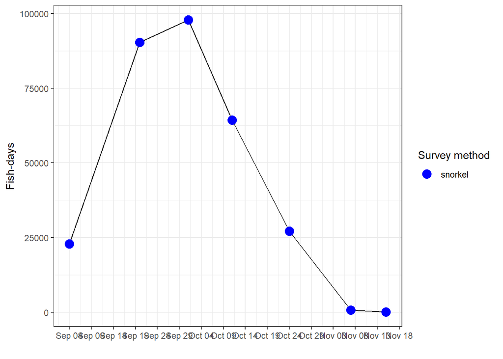

Figure: AUC curve for Nitinat mainstem Chinook.

## 5.7 Area 21-22 preliminary escapement estimates (AUC/PL+D)

Table: Raw swim data (raw and expanded live and dead) for Chinook.

| ShortSpecies | Section_AreaInspected | SDate | WaterTemperature | WaterClarity | LiveAdults | DeadAdults | LiveJacks | DeadJacks | ExpLiveAdults | ExpDeadAdults | ExpLiveJacks | ExpDeadJacks | OverallReliability | EstPctSeen |
| --- | --- | --- | --- | --- | --- | --- | --- | --- | --- | --- | --- | --- | --- | --- |
| CN | CAMPUS CREEK | 2024-11-01 | 9.5 | 3 - 5 m or to Bottom | 1 | NA | NA | NA | 3 | NA | NA | NA | M | 0.6 |
| CN | LITTLE NITINAT RIVER | 2024-10-24 | 99.0 | 1 - 3 m | NA | NA | NA | NA | NA | NA | NA | NA | NA | NA |
| CN | NITINAT RIVER | 2024-07-31 | 14.0 | 3 - 5 m or to Bottom | NA | NA | NA | NA | NA | NA | NA | NA | NA | NA |
| CN | NITINAT RIVER | 2024-09-04 | 13.0 | 3 - 5 m or to Bottom | 1955 | 0 | 23 | NA | 2461 | NA | NA | NA | M | 0.9 |
| CN | NITINAT RIVER | 2024-09-20 | 14.0 | 3 - 5 m or to Bottom | 7293 | 3 | 295 | NA | 8974 | NA | NA | NA | M | 0.9 |
| CN | NITINAT RIVER | 2024-10-01 | 11.0 | 3 - 5 m or to Bottom | 6151 | 22 | NA | NA | 7317 | NA | NA | NA | M | 1.0 |
| CN | NITINAT RIVER | 2024-10-11 | 11.0 | NA | 3049 | 60 | 1 | NA | 3538 | NA | NA | NA | H | 1.0 |
| CN | NITINAT RIVER | 2024-10-23 | 99.0 | 1 - 3 m | 0 | NA | NA | NA | NA | NA | NA | NA | NA | NA |
| CN | NITINAT RIVER | 2024-10-24 | 8.0 | 1 - 3 m | 39 | NA | 1 | NA | 58 | NA | NA | NA | M | 0.8 |
| CN | NITINAT RIVER | 2024-11-07 | 8.0 | 1 - 3 m | 4 | 0 | 0 | NA | 5 | NA | NA | NA | M | 1.0 |
| CN | WORTHLESS CREEK | 2024-10-24 | 99.0 | 1 - 3 m | NA | NA | NA | NA | NA | NA | NA | NA | NA | NA |
| CN | WORTHLESS CREEK | 2024-11-01 | 99.0 | 3 - 5 m or to Bottom | NA | NA | NA | NA | 0 | NA | NA | NA | M | NA |

Table: Escapement estimate options (AUC/PL+D) for each system.

| Year | SystemName | AREA | ShortSpecies | StartingZeroDate | EndingZeroDate | AdultShortResidenceTime | AdultMidResidenceTime_R | AdultLongResidenceTime | JackShortResidenceTime | JackMidResidenceTime_R | JackLongResidenceTime | AUCTotalDays | AdultExpAUCLowValue | AdultExpAUCMidValue_R | AdultExpAUCHighValue | JackExpAUCLowValue | JackExpAUCMidValue_R | JackExpAUCHighValue | AdultExpPLD | JackExpPLD | FinalAdultEstimate | AdultRemovalsReco | FinalJackEstimate | JackRemovalsReco | AdultRemovalsIncluded | JackRemovalsIncluded | EnumerationClass | Notes | IsFinal |
| --- | --- | --- | --- | --- | --- | --- | --- | --- | --- | --- | --- | --- | --- | --- | --- | --- | --- | --- | --- | --- | --- | --- | --- | --- | --- | --- | --- | --- | --- |
| 2024 | Nitinat River, Nitinat Lake | 22 | CN | 2024-08-15 | 2024-11-15 | 15 | 20 | 25 | 15 | 20 | 25 | 92 | 12124 | 15155 | 20206 | 218 | 272 | 363 | 9007 | 364 | 11338 | 3817 | 220 | 52 | TRUE | TRUE | 3 | 6 snorkel surveys (31-July to 7 Nov) of which 3 were Upper+Lower (Oct 1, Oct 11, Nov 7) - not all swims retained for AUC estimate (e.g., 31 July). Sept 4 and 20 % pop reduced as Chinook were already i… | FALSE |
| 2024 | Hobiton Creek | 22 | CN | 2024-09-01 | 2024-11-15 | 15 | 20 | 25 | 15 | 20 | 25 | 0 | 0 | 0 | 0 | 0 | 0 | 0 | 0 | 0 | 0 | 0 | 0 | 0 | FALSE | FALSE | 0 | NA | FALSE |
| 2024 | Campus Creek | 22 | CN | 2024-09-01 | 2024-11-15 | 15 | 20 | 25 | 15 | 20 | 25 | 75 | 3 | 4 | 5 | 0 | 0 | 0 | 2 | 0 | 2 | 0 | 0 | 0 | FALSE | FALSE | 6 | One swim Nov 1. Swam marker 24 to lake, as well as side channel and Borrow Pits. Percent population adjusted to 60% as survey was late for Chinook, the creek recently flooded prior to the swim, and to… | FALSE |
| 2024 | Little Nitinat River | 22 | CN | 2024-09-01 | 2024-11-15 | 15 | 20 | 25 | 15 | 20 | 25 | 75 | 0 | 0 | 0 | 0 | 0 | 0 | 0 | 0 | 0 | 0 | 0 | 0 | FALSE | FALSE | 5 | One heli survey Oct 24 targeted for Chum. No Chinook seen. | FALSE |
| 2024 | Worthless Creek | 22 | CN | 2024-09-01 | 2024-11-15 | 15 | 20 | 25 | 15 | 20 | 25 | 75 | 0 | 0 | 0 | 0 | 0 | 0 | 0 | 0 | 0 | 0 | 0 | 0 | FALSE | FALSE | 6 | Two surveys: Heli Oct 24 and snorkel check Nov 1. No chinook observed. | FALSE |

### 5.7.1 Estimate decision:

For 2024, suggest that swim-ins be subtracted from the mid-point AUC estimate to get to ~10k spawners ultimately. NRH observations fall closer to ~10-11k, and we only saw about 9k adults on swims. The Hatchery also struggled to get broodstock this year and did not meet their brood targets, whereas last year they had no issue and the escapement estimated landed around ~15k. Therefore escapement this year should be considerably lower. Looking at the swim-in timing and spawning, spawning started up after most of the fish swam into the hatchery, which suggests some of the mainstem fish counted on Sept 19 (lower) and even Oct 1 (minimal spawning in the lower). Most swim-ins were into the hatchery by the Oct 11 survey which had a lot of spawning. I would recommend subtracting the swim-ins - even the late bump ~Oct 19 because i think the AUC curve covers this component within the area integrated under the curve. Given this, if we took the mid point estimate of 15155 minus 3817 adult swim-ins leaves 11338 natural adult spawners. Likewise, jacks would end up being 220 natural jack spawners. *This is subject to change; see EscBatchHardCopy report for specific estimate abundance.*

## 5.8 2024 compared to historical run timing and abundances

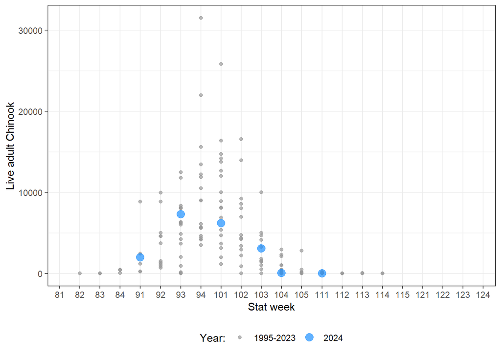

Figure: Raw swim counts (blue) from this year compared to historical raw swim counts. Stat weeks indicate the month (8=August, 12=December) and week of momth (1=first week, 2=2nd week, etc.), e.g., 81=First week of August, 91=First week of September, etc.

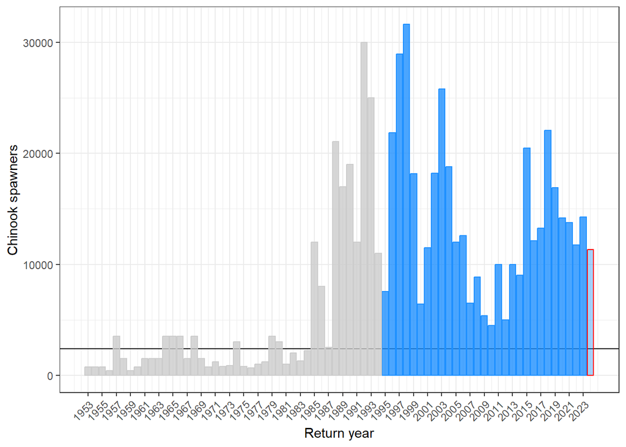

Figure: 2024 preliminary adult Chinook escapement estimate (red outline) relative to historical adult (blue) and unspecified (gray) escapement estimates.

# 6 **Pink**

No consistent WCVI pink runs.

## 6.1 Area 21-22 preliminary escapement estimates

Table: Escapement estimates for each system.

| Year | SystemName | AREA | ShortSpecies | StartingZeroDate | EndingZeroDate | AdultShortResidenceTime | AdultMidResidenceTime_R | AdultLongResidenceTime | JackShortResidenceTime | JackMidResidenceTime_R | JackLongResidenceTime | AUCTotalDays | AdultExpAUCLowValue | AdultExpAUCMidValue_R | AdultExpAUCHighValue | JackExpAUCLowValue | JackExpAUCMidValue_R | JackExpAUCHighValue | AdultExpPLD | JackExpPLD | FinalAdultEstimate | AdultRemovalsReco | FinalJackEstimate | JackRemovalsReco | AdultRemovalsIncluded | JackRemovalsIncluded | EnumerationClass | Notes | IsFinal |
| --- | --- | --- | --- | --- | --- | --- | --- | --- | --- | --- | --- | --- | --- | --- | --- | --- | --- | --- | --- | --- | --- | --- | --- | --- | --- | --- | --- | --- | --- |
| 2024 | Nitinat River, Nitinat Lake | 22 | PK | 2024-09-01 | 2024-11-15 | 15 | 20 | 25 | 15 | 20 | 25 | 108 | 0 | 0 | 0 | 0 | 0 | 0 | 0 | 0 | 0 | 0 | 0 | 0 | FALSE | FALSE | 3 | 6 snorkel surveys (31-July to 7 Nov) of which 3 were Upper+Lower (Oct 1, Oct 11, Nov 7). No pinks seen (none expected). | FALSE |
| 2024 | Campus Creek | 22 | PK | 2024-09-01 | 2024-11-15 | 15 | 20 | 25 | 15 | 20 | 25 | 75 | 0 | 0 | 0 | 0 | 0 | 0 | 0 | 0 | 0 | 0 | 0 | 0 | FALSE | FALSE | 5 | One snorkel survey Nov 1. No Pink observed. | FALSE |
| 2024 | Little Nitinat River | 22 | PK | 2024-09-01 | 2024-11-15 | 15 | 20 | 25 | 15 | 20 | 25 | 75 | 0 | 0 | 0 | 0 | 0 | 0 | 0 | 0 | 0 | 0 | 0 | 0 | FALSE | FALSE | 6 | One heli survey Oct 24 aimed at Chum. No pink observed (none expected) | FALSE |
| 2024 | Worthless Creek | 22 | PK | 2024-09-01 | 2024-11-15 | 15 | 20 | 25 | 15 | 20 | 25 | 75 | 0 | 0 | 0 | 0 | 0 | 0 | 0 | 0 | 0 | 0 | 0 | 0 | FALSE | FALSE | 6 | One survey Nov 1. No pinks noted (none expected). | FALSE |